# Data 605 HW 7

Jean Jimenez

2023-10-09

# HW 7

## Question 1

Let X1, X2, . . . , Xn be n mutually independent random variables, each of which is uniformly distributed on the integers from 1 to k. Let Y denote the minimum of the Xi’s. Find the distribution of Y

### Step One

First, I set n = 10 and k =30, meaning that there will be 10 random variables per trial and 30 is the maximum value. I will be simulating this scenario 30,000 times.

```r
set.seed(10092023)

# Number of random variables
n = 10

# Range of each random variable (1 to k)
k = 30

# Number of simulations
sims = 30000
```

### Step 2

Here, we generate 10 random variables from 1 to 30 using the sample function and allowing for repeating values. We then find the minimum value among the 10 random variables and add it to min_val.

```r
min_val = numeric(sims)

# perform trials

for (i in 1:sims) {
  x = sample(1:k, n, replace = TRUE)
  min_val[i] = min(x)
}
```

### Distribution of Y

This is a histogram that shows the distribution of the minimum values we collected, which is an estimation of the distribution of Y.

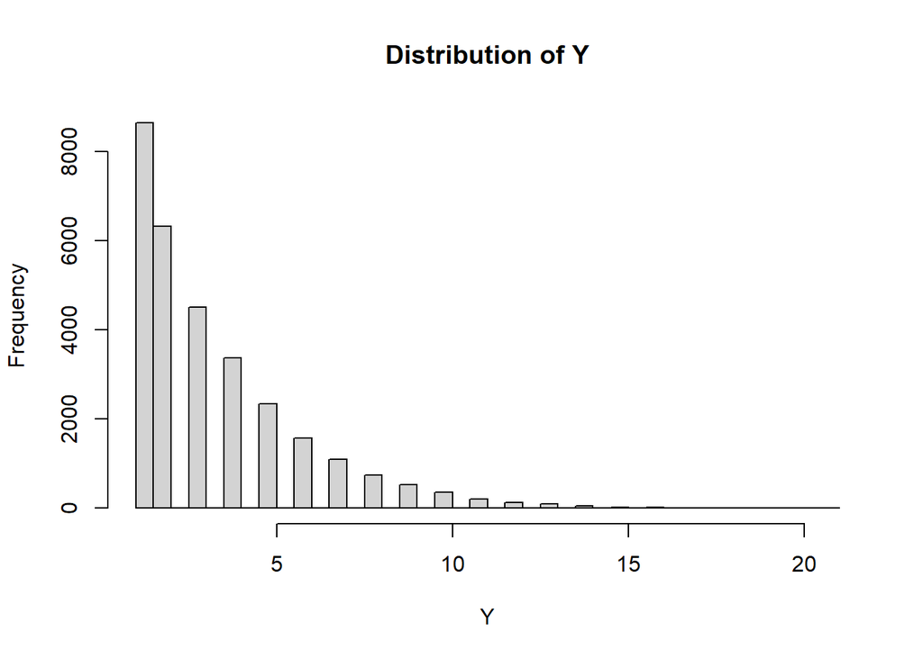

```r
# plotting the distribution of y

hist(min_val, breaks = k, main = "Distribution of Y", xlab = "Y", ylab = "Frequency")
```

## Question 2

Your organization owns a copier (future lawyers, etc.) or MRI (future doctors). This machine has a manufacturer’s expected lifetime of 10 years. This means that we expect one failure every ten years. (Include the probability statements and R Code for each part.).

### Part A

**Geometric**

**Question**

What is the probability that the machine will fail after 8 years?. Provide also the expected value and standard deviation. Model as a geometric. (Hint: the probability is equivalent to not failing during the first 8 years..)

$P(X > 8) = 1 - P(X \leq 8)$

$E[X] = \frac{1}{p}$

```r
#prob of failing any year
p_L_a = 1 / 10

# prob machine will fail after 8 yrs

prob_L_after_8_a = 1 - pgeom(8, prob = p_L_a)

#expected val
exp_val_a=1/p_L_a

std_dev_a=sqrt((1-p_L_a)/p_L_a^1)

cat("The probability that the machine will fail after 8 years is",prob_L_after_8_a,"or",prob_L_after_8_a*100,"% \n")
```

```
## The probability that the machine will fail after 8 years is 0.3874205 or 38.74205 %
```

```r
cat("The expected number of failures in 8 years is",exp_val_a,"failures \n")
```

```
## The expected number of failures in 8 years is 10 failures
```

```r
cat("The standard deviation is +/-",std_dev_a,"failures \n")
```

```
## The standard deviation is +/- 3 failures
```

### Part B

**Exponential**

**Question**

What is the probability that the machine will fail after 8 years?. Provide also the expected value and standard deviation. Model as an exponential.

$P(X > 8) = e^{-\lambda \times 8}$

$E[X] = \frac{1}{\lambda}$

$\sigma= \frac{1}{\lambda}$

```r
# rate of failure per year
lambda_L_b = 1 / 10

# Probability that the machine will fail after 8 years
prob_L_after_8_b = exp(-lambda_L_b * 8)

# expected value

exp_val_b = 1 / lambda_L_b

# standard deviation

std_dev_b = 1 / lambda_L_b

cat("The probability that the machine will fail after 8 years is",prob_L_after_8_b,"or",prob_L_after_8_b*100,"% \n")
```

```
## The probability that the machine will fail after 8 years is 0.449329 or 44.9329 %
```

```r
cat("The expected number of failures in 8 years is",exp_val_b,"failures \n")
```

```
## The expected number of failures in 8 years is 10 failures
```

```r
cat("The standard deviation is +/-",std_dev_b,"failures \n")
```

```
## The standard deviation is +/- 10 failures
```

### Part C

**Binomial**

**Question**

What is the probability that the machine will fail after 8 years?. Provide also the expected value and standard deviation. Model as a binomial. (Hint: 0 success in 8 years)

$P(X=0) = \binom{8}{0} \left( \frac{1}{10} \right)^{0} \left( 1 - \frac{1}{10} \right)^{8}$

$E[X] = n \times p$

$\sigma=\sqrt{n \times p \times (1-p)}$

```r
#n years

n_yrs=8

#prob fail any year

p_L_c=1/10

#prob machine not fail in first 8 yrs
prob_w_first_8_c = dbinom(0, size = n_yrs, prob = p_L_c)

#prob will after 1st 8 yrs
prob_L_after_8_c = 1 - prob_w_first_8_c

# exp val
exp_val_c = n_yrs * p_L_c

# stdev
std_dev_c = sqrt(n_yrs* p_L_c * (1 - p_L_c))


cat("The probability that the machine will fail after 8 years is",prob_w_first_8_c,"or",prob_w_first_8_c*100,"% \n")
```

```
## The probability that the machine will fail after 8 years is 0.4304672 or 43.04672 %
```

```r
cat("The expected number of failures in 8 years is",exp_val_c,"failures \n")
```

```
## The expected number of failures in 8 years is 0.8 failures
```

```r
cat("The standard deviation is +/-",std_dev_c,"failures \n")
```

```
## The standard deviation is +/- 0.8485281 failures
```

### Part D

**Poisson**

**Question**

What is the probability that the machine will fail after 8 years?. Provide also the expected value and standard deviation. Model as a Poisson.

$P(X=0) = \frac{\lambda^0 \times e^{-\lambda}}{0!}$

$E[X] = \lambda$

$\sigma=\sqrt{\lambda}$

```r
# avg rate of failure in 8 ysr

lambda_L_d = 8 / 10

# Prob that machine will not fail in the first 8 yrs

prob_w_first_8_d= dpois(0, lambda_L_d)
prob_L_after_8_d = 1 - prob_w_first_8_d

#expected
exp_val_d=lambda_L_d

#std dev
std_dev_d=sqrt(lambda_L_d)


cat("The probability that the machine will fail after 8 years is",prob_L_after_8_d,"or",prob_L_after_8_d*100,"% \n")
```

```
## The probability that the machine will fail after 8 years is 0.550671 or 55.0671 %
```

```r
cat("The expected number of failures in 8 years is",exp_val_d,"failures \n")
```

```
## The expected number of failures in 8 years is 0.8 failures
```

```r
cat("The standard deviation is +/-",std_dev_d,"failures \n")
```

```
## The standard deviation is +/- 0.8944272 failures
```